# Análise dos Dados das Eleições de 2016

### A importância do Voto

##### Author: Rodrigo Brust

#### [Linkedin](https://www.linkedin.com/in/rodrigobrust/) | [Github](https://github.com/rodreras)

### Summary

1.Importing Data

2.Analizando os Dados do 2° Turno - parte 1

3.Análise IDH

4.Vencedores das Zonas Eleitorais

5.Analizando os Dados do 2° Turno - parte 2

6.Analize Espacial dos Brancos, Nulos e Abstenções

7.Buscando Correlações

8.Conclusões

```python
import pandas as pd
import matplotlib.pyplot as plt
import geopandas as gpd
import seaborn as sb
from seaborn import color_palette
import numpy as np
import re
import folium
from folium import Choropleth
```

### Importando dados

Voltar para o topo

##### Detalhes da última eleição

```python
#importando dados de detalhe da votação eleição 2016 por município e zona eleitoral
detalhe = pd.read_csv('detalhe_votacao_munzona_2016_RJ.csv',sep = ';',encoding = "latin-1")
```

##### Importando dados do IDH do RJ

```python
file2 = 'idh_bairros_rj.csv'
idh = pd.read_csv(file2, sep = ';', encoding = 'latin-1')
```

```python
idh['idh'] = idh.idh.str.replace(',','.')
```

```python
idh.head()
```

|  | num | NOME | longe | alfabetizacao | freq_escolar | renda_capita | idhl | idhe | idhr | idh |
| --- | --- | --- | --- | --- | --- | --- | --- | --- | --- | --- |
| 0 | 1 | Abolição | 73,28 | 97,07 | 95,69 | 467,23 | 0,805 | 0,966 | 0,799 | 0.857 |
| 1 | 2 | Acari | 63,93 | 91,68 | 79,44 | 174,12 | 0,649 | 0,876 | 0,634 | 0.72 |
| 2 | 3 | Água Santa | 76,21 | 97,48 | 95,65 | 496,66 | 0,853 | 0,969 | 0,809 | 0.877 |
| 3 | 4 | Alto da Boa Vista | 75,04 | 98,02 | 107,38 | 1204,61 | 0,834 | 0,987 | 0,957 | 0.926 |
| 4 | 5 | Anchieta | 68,9 | 95,65 | 84,75 | 278,18 | 0,732 | 0,92 | 0,712 | 0.788 |

```python
idh['idh'] = pd.to_numeric(idh['idh'])
```

```python
idh.info()
```

```
<class 'pandas.core.frame.DataFrame'>
RangeIndex: 163 entries, 0 to 162
Data columns (total 10 columns):
 #   Column         Non-Null Count  Dtype
---  ------         --------------  -----
 0   num            163 non-null    int64
 1   NOME           163 non-null    object
 2   longe          163 non-null    object
 3   alfabetizacao  163 non-null    object
 4   freq_escolar   163 non-null    object
 5   renda_capita   163 non-null    object
 6   idhl           163 non-null    object
 7   idhe           163 non-null    object
 8   idhr           163 non-null    object
 9   idh            163 non-null    float64
dtypes: float64(1), int64(1), object(8)
memory usage: 12.9+ KB
```

##### Importanto dados dos bairros do RJ em shp

```python
file3 = "bairros/bairros.shp"

bairros = gpd.read_file(file3)
```

```python
bairros = bairros.sort_values(by=['NOME'])
```

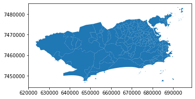

```python
bairros.plot()
```

```python
lista_bairro = bairros.NOME.to_list()
lista_bairro.sort()
```

##### Importando dados das zonas eleitorais do RJ em shp

```python
file4 = 'eleitoral_zonas_2016/eleitoral_zonas_2016.shp'

ze = gpd.read_file(file4)
```

```python
ze_rj = ze[ze.municipio == 'RIO DE JANEIRO']
```

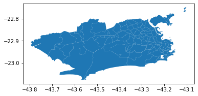

```python
ze_rj.plot()
```

```python
#criando um dataframe onde tenha apenas a cidade do RJ
detalhe_rj = detalhe[detalhe.NM_MUNICIPIO == 'RIO DE JANEIRO']
```

```python
#criando outro df, mas dessa vez onde tenha apenas os votos do segundo turno
detalhe_rj_2t = detalhe_rj[detalhe_rj.NR_TURNO == 2]
```

##### Importando Resultados da Eleição 2016 2T Rio de Janeiro

```python
#agora vamos importar a votação por seção em 2016
file = 'votacao_secao_2016_RJ.txt'
resultado = pd.read_csv(file, sep = ';', encoding ='latin-1', header = None)
```

```python
resultado.columns = ['data_geracao','hora_geracao','ano_eleicao','turno','descricao_eleicao','sigla_uf',
                    'sigla_ue','cod_mun','nm_mun','num_zona','num_secao','codigo_cargo','descricao_cargo',
                    'num_votavel','num_votos']
```

### Criando filtros, vendo estruturas de dados

```python
#criando um df apenas com o municipio do RJ
resultado_rj = resultado[resultado.cod_mun == 60011]
```

```python
#criando um df com apenas o municipio do RJ e o segundo turno
resultado_rj_2t = resultado_rj[resultado_rj.turno == 2]
```

### Analizando as porcentagens dos votos no 2° Turno de 2016

Voltar para o topo

```python
#numero de votos que cada candidato recebeu
#10 - Crivela 50 - Freixo 95 - Branco 96 - Nulo
votos_final = resultado_rj_2t.groupby(['num_votavel']).sum()
```

```python
tot = resultado_rj_2t.num_votos.sum()
```

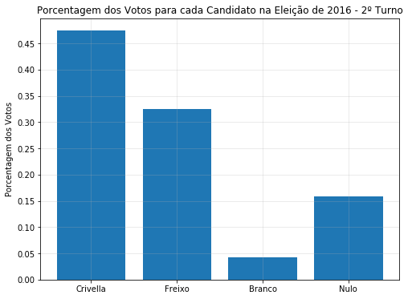

```python
#porcentagem de votos de cada um
crivella = 1700030/tot
freixo = 1163662/tot
branco = 149866/tot
nulo = 569536/tot

candidatos = [crivella,freixo,branco,nulo]
nomes = ['Crivella','Freixo','Branco','Nulo']

plt.figure(figsize = [8,6])
plt.bar(x = nomes, height = candidatos)
plt.grid(True, alpha = 0.3)
plt.title('Porcentagem dos Votos para cada Candidato na Eleição de 2016 - 2º Turno')
plt.ylabel('Porcentagem dos Votos')
plt.yticks(np.arange(0,0.5,0.05));
```

- Resultado da Eleição Municipal do Rio de Janeiro de 2016.
- Marcelo Crivella do Republicanos foi eleito prefeito do Rio de Janeiro, derrotando o candidato do PSOL Marcelo Freixo.

### Fazendo análise do IDH dos bairros do RJ

Voltar para o topo

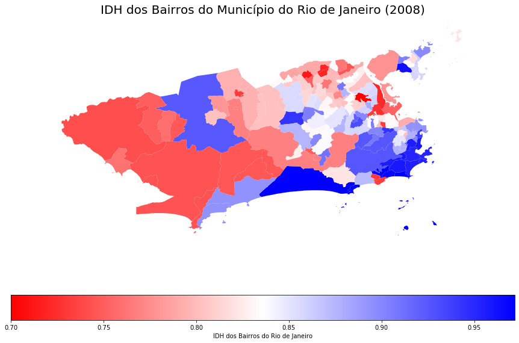

```python
#unindo o gdf bairros com o df idh
rio_idh = bairros.merge(idh, on = 'NOME', how = 'outer')

#plotando os dados

rio_idh.plot(column = 'idh', legend = True,figsize=(15, 10), cmap = 'bwr_r',
             legend_kwds={'label':'IDH dos Bairros do Rio de Janeiro', 'orientation':'horizontal'})
plt.xticks(rotation = 90)
plt.axis('off')
plt.title('IDH dos Bairros do Município do Rio de Janeiro (2008)', fontsize = 20)
plt.savefig('rio_idh.jpg');
```

- O Rio de Janeiro é uma cidade com mais de 6 milhões de habitantes. Marcada pelas praias e montanhas, também abriga uma enorme desigualdade social.
- Regiões mais próximas ao Centro da Cidade são as mais ricas, e também mais famosas, como por exemplo `Ipanema`, `Copacabana`, `Barra da Tijuca`.
- As reigões menos abastadas localizam-se na Zona Oeste e Zona Norte, conforme apontado pelo mapa de IDH dos Bairros acima.

### Ajustando os dados para ver os vencedores em cada Zona Eleitoral nas Eleições de 2016

Voltar para o topo

```python
#retirando as letras do numero da zona
ze_rj['num_zona'] = ze_rj.zona.str.extract('([a-zA-Z0-9-]+)')
```

```python
#transformando em int
ze_rj['num_zona'] = ze_rj.num_zona.astype('int')
```

```python
#analizando as zonas eleitoras em ordem crescente
ze_rj.sort_values(by=['num_zona'])
```

|  | id | cd_mun | municipio | cd_craai | zona | nome | geometry | num_zona |
| --- | --- | --- | --- | --- | --- | --- | --- | --- |
| 86 | 171 | 3304557 | RIO DE JANEIRO | 10 | 001ª | 001ª Capital | POLYGON Z ((-43.19992 -22.90186 0.00000, -43.2... | 1 |
| 87 | 172 | 3304557 | RIO DE JANEIRO | 10 | 001ª | 001ª Ilha de Paquetá | POLYGON Z ((-43.10939 -22.74899 0.00000, -43.1... | 1 |
| 88 | 173 | 3304557 | RIO DE JANEIRO | 10 | 002ª | 002ª Ilha Santa B | POLYGON Z ((-43.19651 -22.88720 0.00000, -43.1... | 2 |
| 90 | 174 | 3304557 | RIO DE JANEIRO | 10 | 002ª | 002ª Capital | POLYGON Z ((-43.21057 -22.89769 0.00000, -43.2... | 2 |
| 91 | 175 | 3304557 | RIO DE JANEIRO | 10 | 002ª | 002ª Ilha das Enxadas | POLYGON Z ((-43.17560 -22.88280 0.00000, -43.1... | 2 |
| ... | ... | ... | ... | ... | ... | ... | ... | ... |
| 165 | 256 | 3304557 | RIO DE JANEIRO | 10 | 243ª | 243ª Capital | POLYGON Z ((-43.54768 -22.93832 0.00000, -43.5... | 243 |
| 166 | 257 | 3304557 | RIO DE JANEIRO | 10 | 244ª | 244ª Capital | POLYGON Z ((-43.55910 -22.90209 0.00000, -43.5... | 244 |
| 167 | 258 | 3304557 | RIO DE JANEIRO | 10 | 245ª | 245ª Capital | POLYGON Z ((-43.56629 -22.90348 0.00000, -43.5... | 245 |
| 168 | 259 | 3304557 | RIO DE JANEIRO | 10 | 246ª | 246ª Capital | POLYGON Z ((-43.66327 -22.86851 0.00000, -43.6... | 246 |
| 169 | 260 | 3304557 | RIO DE JANEIRO | 10 | 252ª | 252ª Capital | POLYGON Z ((-43.19860 -22.97804 0.00000, -43.1... | 252 |

102 rows × 8 columns

```python
#vendo o número de votos que cada candidato recebeu
resultado_rj_2t.groupby(['num_votavel'])[['num_votos']].sum()
```

| num_votavel | num_votos |
| --- | --- |
| 10 | 1700030 |
| 50 | 1163662 |
| 95 | 149866 |
| 96 | 569536 |

```python
#criando um df onde faça o groupby a partir do numero da zona e o número da legenda do candidato
zone_candidato = resultado_rj_2t.groupby(['num_zona','num_votavel'])[['num_votos']].sum()
```

```python
#resetando o index do df.
zone_candidato.reset_index(inplace = True)
```

```python
#checando as atualizações
zone_candidato.head()
```

|  | num_zona | num_votavel | num_votos |
| --- | --- | --- | --- |
| 0 | 1 | 10 | 7523 |
| 1 | 1 | 50 | 6535 |
| 2 | 1 | 95 | 710 |
| 3 | 1 | 96 | 2218 |
| 4 | 2 | 10 | 16918 |

```python
#criando um df em que puxa os candidatos que tiveram mais votos na seção, porém, ainda não dá pra saber quem foi o candidato eleito
zone_result = zone_candidato.groupby(['num_zona'])[['num_votos']].max()
```

```python
#agrupando os resultados
zona_candidato = zone_candidato.groupby(['num_votavel','num_zona'])[['num_votos']].sum()
```

```python
#analizando os locais onde o número de votsos do df zone_result é igual ao número de votos no df zone_candidatos
#assim, podendo saber se os números batem e em qual candidato foi o mais votado
zone_result_candidate = (zone_candidato['num_votos'].isin(zone_result['num_votos']))
```

```python
#transformando em um df
zone_result_candidate.head(20)
```

```
0      True
1     False
2     False
3     False
4      True
5     False
6     False
7     False
8     False
9      True
10    False
11    False
12    False
13     True
14    False
15    False
16    False
17     True
18    False
19    False
Name: num_votos, dtype: bool
```

```python
#selecionando apenas as linhas que possuem True
zone_result_candidate = zone_result_candidate[zone_result_candidate == True]
```

```python
#fazendo o merge
ze_vencedores = zone_candidato.merge(zone_result_candidate, left_index = True, right_index = True)
ze_vencedores.head()
```

|  | num_zona | num_votavel | num_votos_x | num_votos_y |
| --- | --- | --- | --- | --- |
| 0 | 1 | 10 | 7523 | True |
| 4 | 2 | 10 | 16918 | True |
| 9 | 3 | 50 | 13714 | True |
| 13 | 4 | 50 | 17529 | True |
| 17 | 5 | 50 | 9936 | True |

```python
#dropando uma zona duplicada
ze_vencedores.drop([252], inplace = True)
```

```python
ze_vencedores.tail(5)
```

|  | num_zona | num_votavel | num_votos_x | num_votos_y |
| --- | --- | --- | --- | --- |
| 368 | 243 | 10 | 28401 | True |
| 372 | 244 | 10 | 14859 | True |
| 376 | 245 | 10 | 32068 | True |
| 380 | 246 | 10 | 48602 | True |
| 385 | 252 | 50 | 12327 | True |

```python
#fazer o merge entre o gpd e o dataframe alterado
ze_rj_vencedores = ze_rj.merge(ze_vencedores, on = 'num_zona', how = 'outer')
```

```python
#analisando de forma crescente as zonas eleitorais
ze_rj_vencedores.sort_values(by = 'num_zona')
```

|  | id | cd_mun | municipio | cd_craai | zona | nome | geometry | num_zona | num_votavel | num_votos_x | num_votos_y |
| --- | --- | --- | --- | --- | --- | --- | --- | --- | --- | --- | --- |
| 7 | 171.0 | 3304557 | RIO DE JANEIRO | 10 | 001ª | 001ª Capital | POLYGON Z ((-43.19992 -22.90186 0.00000, -43.2... | 1 | 10 | 7523 | True |
| 8 | 172.0 | 3304557 | RIO DE JANEIRO | 10 | 001ª | 001ª Ilha de Paquetá | POLYGON Z ((-43.10939 -22.74899 0.00000, -43.1... | 1 | 10 | 7523 | True |
| 9 | 173.0 | 3304557 | RIO DE JANEIRO | 10 | 002ª | 002ª Ilha Santa B | POLYGON Z ((-43.19651 -22.88720 0.00000, -43.1... | 2 | 10 | 16918 | True |
| 10 | 174.0 | 3304557 | RIO DE JANEIRO | 10 | 002ª | 002ª Capital | POLYGON Z ((-43.21057 -22.89769 0.00000, -43.2... | 2 | 10 | 16918 | True |
| 11 | 175.0 | 3304557 | RIO DE JANEIRO | 10 | 002ª | 002ª Ilha das Enxadas | POLYGON Z ((-43.17560 -22.88280 0.00000, -43.1... | 2 | 10 | 16918 | True |
| ... | ... | ... | ... | ... | ... | ... | ... | ... | ... | ... | ... |
| 85 | 256.0 | 3304557 | RIO DE JANEIRO | 10 | 243ª | 243ª Capital | POLYGON Z ((-43.54768 -22.93832 0.00000, -43.5... | 243 | 10 | 28401 | True |
| 86 | 257.0 | 3304557 | RIO DE JANEIRO | 10 | 244ª | 244ª Capital | POLYGON Z ((-43.55910 -22.90209 0.00000, -43.5... | 244 | 10 | 14859 | True |
| 87 | 258.0 | 3304557 | RIO DE JANEIRO | 10 | 245ª | 245ª Capital | POLYGON Z ((-43.56629 -22.90348 0.00000, -43.5... | 245 | 10 | 32068 | True |
| 88 | 259.0 | 3304557 | RIO DE JANEIRO | 10 | 246ª | 246ª Capital | POLYGON Z ((-43.66327 -22.86851 0.00000, -43.6... | 246 | 10 | 48602 | True |
| 89 | 260.0 | 3304557 | RIO DE JANEIRO | 10 | 252ª | 252ª Capital | POLYGON Z ((-43.19860 -22.97804 0.00000, -43.1... | 252 | 50 | 12327 | True |

103 rows × 11 columns

```python
ze_rj_vencedores['num_zona'].duplicated().sum()
```

```
6
```

```python
ze_rj_vencedores['num_zona'].drop_duplicates(inplace=True)
```

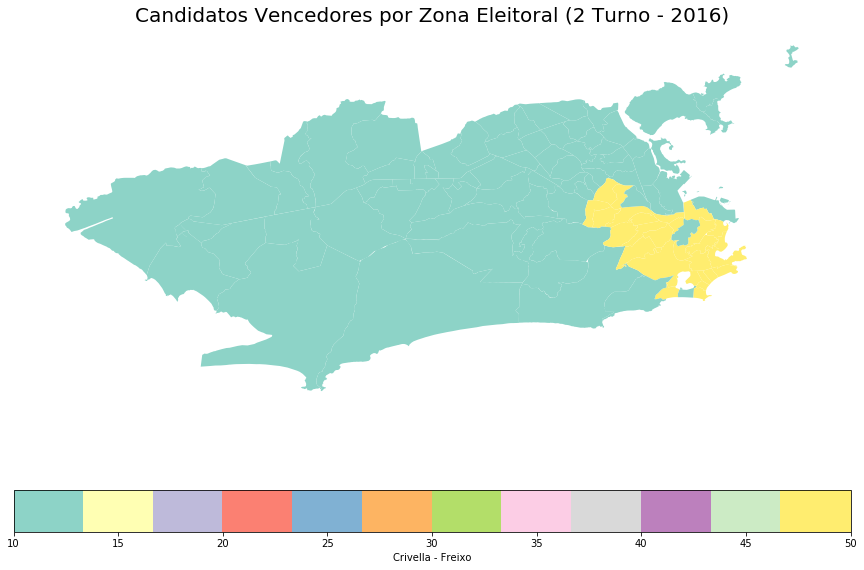

```python
#plotando o mapa onde cada candidato venceu
#Azul - Crivella
#Vermelho - Freixo
ax = ze_rj_vencedores.plot(column = 'num_votavel',
                     figsize = (15,10), cmap = 'Set3', legend = True,
                           legend_kwds = {'label' :'Crivella - Freixo', 'orientation':'horizontal'})
ax.set_title('Candidatos Vencedores por Zona Eleitoral (2 Turno - 2016)', fontsize = 20)
ax.axis('off');
```

- O candidato eleito Prefeito para do quadriênio (2017-2020) foi o Marcelo Crivella (REP), com 1.700.030 de votos. Já o seu concorrente, Marcelo Freixo (PSOL), ficou em segundo lugar com 1.1636.62 de votos. É bastante claro como o discurso do PSOL não é capaz de atingir as áreas com IDH menor, e isso se dá por diversos fatores, como por exemplo:
  - presença de forças paralelas
  - discurso muito elitizado
  - falta de presença no dia-a-dia da população
- Outro fator que ajudou Crivella a vencer foi o fato dele ser Bispo, e grande parcela da população do Rio de Janeiro é evangélica. Isso muito provavelmente foi um fator que o auxiliou a angariar votos.
- Em 2016 havia uma crescente onda do medo contra partidos de esquerda, onde estes supostamente iriam implementar o comunismo no Rio de Janeiro/Brasil, tirando muitos votos do PSOL. Também nesse época, crescia o conservadorismo no país, puxado pelo então pré-candidato a Presidência Jair Bolsonaro.

### Analizando os dados do 2° Turno das Eleições de 2016

Voltar para o topo

### Próximas Análises

- Zona com maior número de abstenções ✅
- Zona com maior número de aptos ✅
- Top 10 Zonas com maior número de abstenções ✅
- Top 10 Zonas com maior número de votos nulos ✅
- Top 10 Zonas com maior número de votos brancos ✅

```python
#puxando os dados que serão utilizados
detalhe_rj_2t.head()
```

|  | DT_GERACAO | HH_GERACAO | ANO_ELEICAO | CD_TIPO_ELEICAO | NM_TIPO_ELEICAO | NR_TURNO | CD_ELEICAO | DS_ELEICAO | DT_ELEICAO | TP_ABRANGENCIA | ... | QT_ABSTENCOES | ST_VOTO_EM_TRANSITO | QT_VOTOS_NOMINAIS | QT_VOTOS_BRANCOS | QT_VOTOS_NULOS | QT_VOTOS_LEGENDA | QT_VOTOS_PENDENTES | QT_VOTOS_ANULADOS | HH_ULTIMA_TOTALIZACAO | DT_ULTIMA_TOTALIZACAO |
| --- | --- | --- | --- | --- | --- | --- | --- | --- | --- | --- | --- | --- | --- | --- | --- | --- | --- | --- | --- | --- | --- |
| 9 | 18/10/2020 | 00:06:22 | 2016 | 2 | Eleição Ordinária | 2 | 221 | ELEIÇÕES MUNICIPAIS 2016 | 30/10/2016 | M | ... | 9714 | N | 19976 | 1079 | 5096 | 0 | 0 | 0 | 20:40:16 | 30/10/2016 |
| 13 | 18/10/2020 | 00:06:22 | 2016 | 2 | Eleição Ordinária | 2 | 221 | ELEIÇÕES MUNICIPAIS 2016 | 30/10/2016 | M | ... | 8002 | N | 14134 | 601 | 3236 | 0 | 0 | 0 | 20:40:16 | 30/10/2016 |
| 19 | 18/10/2020 | 00:06:22 | 2016 | 2 | Eleição Ordinária | 2 | 221 | ELEIÇÕES MUNICIPAIS 2016 | 30/10/2016 | M | ... | 11320 | N | 25474 | 1169 | 5820 | 0 | 0 | 0 | 20:40:16 | 30/10/2016 |
| 20 | 18/10/2020 | 00:06:22 | 2016 | 2 | Eleição Ordinária | 2 | 221 | ELEIÇÕES MUNICIPAIS 2016 | 30/10/2016 | M | ... | 17993 | N | 36544 | 1933 | 8590 | 0 | 0 | 0 | 20:40:16 | 30/10/2016 |
| 25 | 18/10/2020 | 00:06:22 | 2016 | 2 | Eleição Ordinária | 2 | 221 | ELEIÇÕES MUNICIPAIS 2016 | 30/10/2016 | M | ... | 14513 | N | 49433 | 2433 | 8964 | 0 | 0 | 0 | 20:40:16 | 30/10/2016 |

5 rows × 34 columns

```python
#vendo suas dimensões
detalhe_rj_2t.shape
```

```
(97, 34)
```

```python
df = detalhe_rj_2t.filter(['NR_ZONA', 'QT_APTOS',
       'QT_SECOES', 'QT_APTOS_TOT', 'QT_SECOES_TOT',
       'QT_COMPARECIMENTO', 'QT_ABSTENCOES', 'QT_VOTOS_NOMINAIS',
                           'QT_VOTOS_BRANCOS', 'QT_VOTOS_NULOS',
       'QT_VOTOS_LEGENDA', 'QT_VOTOS_PENDENTES', 'QT_VOTOS_ANULADOS'])
```

```python
df.head()
```

|  | NR_ZONA | QT_APTOS | QT_SECOES | QT_APTOS_TOT | QT_SECOES_TOT | QT_COMPARECIMENTO | QT_ABSTENCOES | QT_VOTOS_NOMINAIS | QT_VOTOS_BRANCOS | QT_VOTOS_NULOS | QT_VOTOS_LEGENDA | QT_VOTOS_PENDENTES | QT_VOTOS_ANULADOS |
| --- | --- | --- | --- | --- | --- | --- | --- | --- | --- | --- | --- | --- | --- |
| 9 | 14 | 35865 | 85 | 35865 | 85 | 26151 | 9714 | 19976 | 1079 | 5096 | 0 | 0 | 0 |
| 13 | 228 | 25973 | 73 | 25973 | 73 | 17971 | 8002 | 14134 | 601 | 3236 | 0 | 0 | 0 |
| 19 | 216 | 43783 | 101 | 43783 | 101 | 32463 | 11320 | 25474 | 1169 | 5820 | 0 | 0 | 0 |
| 20 | 192 | 65060 | 145 | 65060 | 145 | 47067 | 17993 | 36544 | 1933 | 8590 | 0 | 0 | 0 |
| 25 | 120 | 75343 | 181 | 75343 | 181 | 60830 | 14513 | 49433 | 2433 | 8964 | 0 | 0 | 0 |

```python
#colocando o cabeçalho como letras minúsculas
df.rename(str.lower,axis = 'columns', inplace = True)
```

```python
#vendo os dados primários
apto = df.qt_aptos.sum()
comp = df.qt_comparecimento.sum()
print('Um total de {} pessoas compareceram, embora {} eleitores estavam aptos para votar.'.format(comp,apto))
print('______________________________________________')
print('O número de abstenções foi de {} eleitores.'.format(apto-comp))
percen_abst = ((apto-comp)/apto)*100
print('______________________________________________')
print('Isso representa um total de {:.2f}% dos eleitores que decidiram não votar.'.format(percen_abst))
```

```
Um total de 3583094 pessoas compareceram, embora 4898044 eleitores estavam aptos para votar.
______________________________________________
O número de abstenções foi de 1314950 eleitores.
______________________________________________
Isso representa um total de 26.85% dos eleitores que decidiram não votar.
```

```python
#fazendo um groupby para analisar os numeros por zona
df_sum = df.groupby(['nr_zona']).sum()
```

##### A zona eleitoral com o maior número/ porcentagem de votos em branco

```python
#a zona eleitoral com o maior número/ porcentagem de votos em branco

df_sum.loc[df_sum['qt_votos_brancos'] == df_sum['qt_votos_brancos'].max()] / df_sum['qt_aptos'][179]*100
```

| nr_zona | qt_aptos | qt_secoes | qt_aptos_tot | qt_secoes_tot | qt_comparecimento | qt_abstencoes | qt_votos_nominais | qt_votos_brancos | qt_votos_nulos | qt_votos_legenda | qt_votos_pendentes | qt_votos_anulados |
| --- | --- | --- | --- | --- | --- | --- | --- | --- | --- | --- | --- | --- |
| 179 | 100.0 | 0.221328 | 100.0 | 0.221328 | 73.50913 | 26.49087 | 60.607662 | 3.590807 | 9.310661 | 0.0 | 0.0 | 0.0 |

##### A zona eleitoral com o maior número de votos em branco

```python
#a zona eleitoral com o maior número de votos em branco

df_sum.loc[df_sum['qt_votos_brancos'] == df_sum['qt_votos_brancos'].max()]
```

| nr_zona | qt_aptos | qt_secoes | qt_aptos_tot | qt_secoes_tot | qt_comparecimento | qt_abstencoes | qt_votos_nominais | qt_votos_brancos | qt_votos_nulos | qt_votos_legenda | qt_votos_pendentes | qt_votos_anulados |
| --- | --- | --- | --- | --- | --- | --- | --- | --- | --- | --- | --- | --- |
| 179 | 121087 | 268 | 121087 | 268 | 89010 | 32077 | 73388 | 4348 | 11274 | 0 | 0 | 0 |

```python
#a zona eleitoral com o maior  porcentagem de votos em branco

df_sum.loc[df_sum['qt_votos_nulos'] == df_sum['qt_votos_nulos'].max()] / df_sum['qt_aptos'][9]*100
```

| nr_zona | qt_aptos | qt_secoes | qt_aptos_tot | qt_secoes_tot | qt_comparecimento | qt_abstencoes | qt_votos_nominais | qt_votos_brancos | qt_votos_nulos | qt_votos_legenda | qt_votos_pendentes | qt_votos_anulados |
| --- | --- | --- | --- | --- | --- | --- | --- | --- | --- | --- | --- | --- |
| 9 | 100.0 | 0.221729 | 100.0 | 0.221729 | 74.493927 | 25.506073 | 57.975529 | 3.675144 | 12.843254 | 0.0 | 0.0 | 0.0 |

##### A zona eleitoral com o maior número de votos nulo

```python
#a zona eleitoral com o maior número de votos nulo
df_sum.loc[df_sum['qt_votos_nulos'] == df_sum['qt_votos_nulos'].max()]
```

| nr_zona | qt_aptos | qt_secoes | qt_aptos_tot | qt_secoes_tot | qt_comparecimento | qt_abstencoes | qt_votos_nominais | qt_votos_brancos | qt_votos_nulos | qt_votos_legenda | qt_votos_pendentes | qt_votos_anulados |
| --- | --- | --- | --- | --- | --- | --- | --- | --- | --- | --- | --- | --- |
| 9 | 111397 | 247 | 111397 | 247 | 82984 | 28413 | 64583 | 4094 | 14307 | 0 | 0 | 0 |

```python
#creating a function to make a bar plot
def bar_plot(x, height, title, xlabel, ylabel):
    plt.figure(figsize=[8,8])
    plt.bar(height = height, x =x)
    plt.title(title)
    plt.xlabel(xlabel)
    plt.ylabel(ylabel);
    plt.grid(True, alpha = 0.3, axis = 'y')
```

```python
#Top 10 zonas eleitorais com maior número de abstenções
top10_abs = df_sum['qt_abstencoes'].sort_values(ascending=False)[:10].reset_index()
```

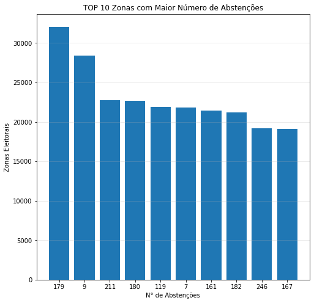

```python
x_abs = top10_abs['nr_zona'].astype('str')
height = top10_abs['qt_abstencoes']
bar_plot(x=x_abs, height = height, title = 'TOP 10 Zonas com Maior Número de Abstenções',
        xlabel = 'N° de Abstenções',ylabel ='Zonas Eleitorais')
```

```python
#Top 10 zonas eleitorais com maior número de votos nulos
top10_vn = df_sum['qt_votos_nulos'].sort_values(ascending=False)[:10].reset_index()
```

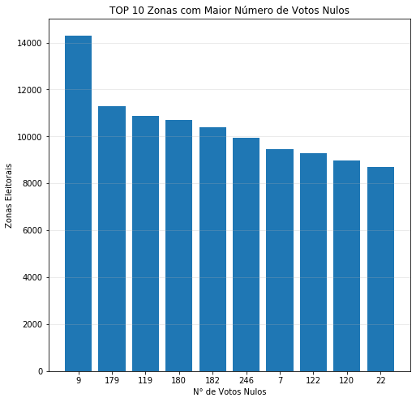

```python
x_vn = top10_vn['nr_zona'].astype('str')
height = top10_vn['qt_votos_nulos']
bar_plot(x=x_vn, height = height, title = 'TOP 10 Zonas com Maior Número de Votos Nulos',
        xlabel = 'N° de Votos Nulos',ylabel ='Zonas Eleitorais')
```

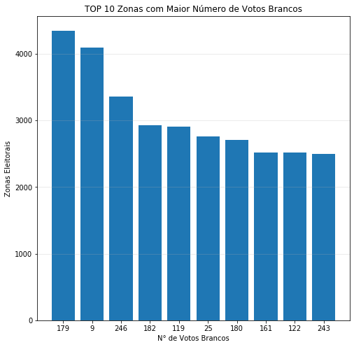

```python
#Top 10 zonas eleitorais com maior número de votos nulos
top10_br = df_sum['qt_votos_brancos'].sort_values(ascending=False)[:10].reset_index()
x_br = top10_br['nr_zona'].astype('str')
height = top10_br['qt_votos_brancos']
bar_plot(x=x_br, height = height, title = 'TOP 10 Zonas com Maior Número de Votos Brancos',
        xlabel = 'N° de Votos Brancos',ylabel ='Zonas Eleitorais')
```

### Análise Espacial dos Brancos, Nulos e Abstenções

Voltar para o topo

```python
df_sum = df_sum.reset_index()
```

```python
df_sum.rename(columns={'nr_zona':'num_zona'}, inplace=True)
```

```python
#unindo os df pra poder ter dados espaciais
gpd_sum = ze_rj.merge(df_sum, on = 'num_zona', how = 'outer')
```

```python
#criando colunas com os valores percentuais de cada situação
gpd_sum['porcen_abstencoes'] = (gpd_sum.qt_abstencoes / gpd_sum['qt_aptos'])*100
gpd_sum['porcen_nulos'] = (gpd_sum.qt_votos_nulos / gpd_sum['qt_aptos'])*100
gpd_sum['porcen_brancos'] = (gpd_sum.qt_votos_brancos / gpd_sum['qt_aptos'])*100
gpd_sum['porcen_eleitores'] = (gpd_sum.qt_aptos / gpd_sum['qt_aptos'].sum())*100
gpd_sum['porcen_votos'] = (gpd_sum.qt_votos_nominais / gpd_sum['qt_aptos'])*100
```

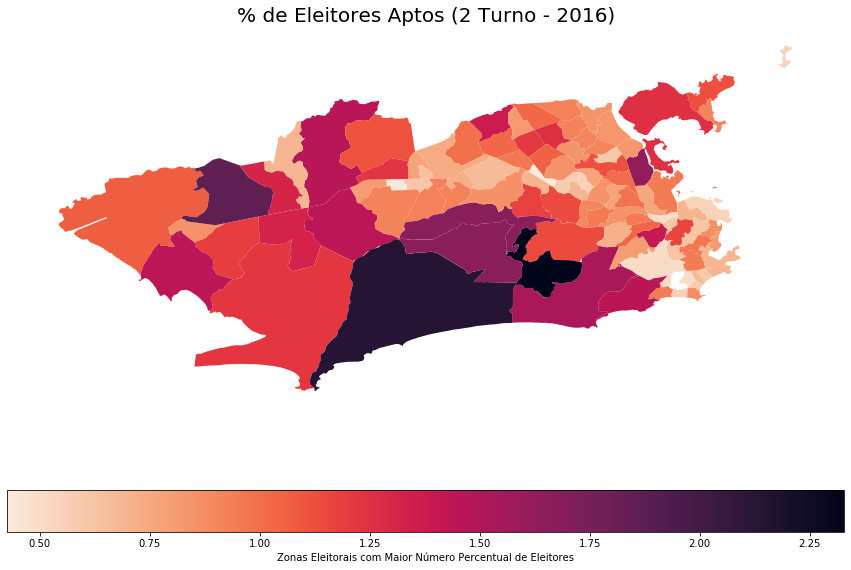

```python
#zonas eleitorais com maior número de eleitores
ax = gpd_sum.plot(column = 'porcen_eleitores',
                     figsize = (15,10), cmap = 'rocket_r', legend = True,
                           legend_kwds = {'label' :'Zonas Eleitorais com Maior Número Percentual de Eleitores',
                                          'orientation':'horizontal'})
ax.set_title('% de Eleitores Aptos (2 Turno - 2016)', fontsize = 20)
ax.axis('off');
```

- Zonas Eleitorais da Zona Oeste por serem maiores e abrangerem mais bairros, acabam tendo mais eleitores aptos para a votação.

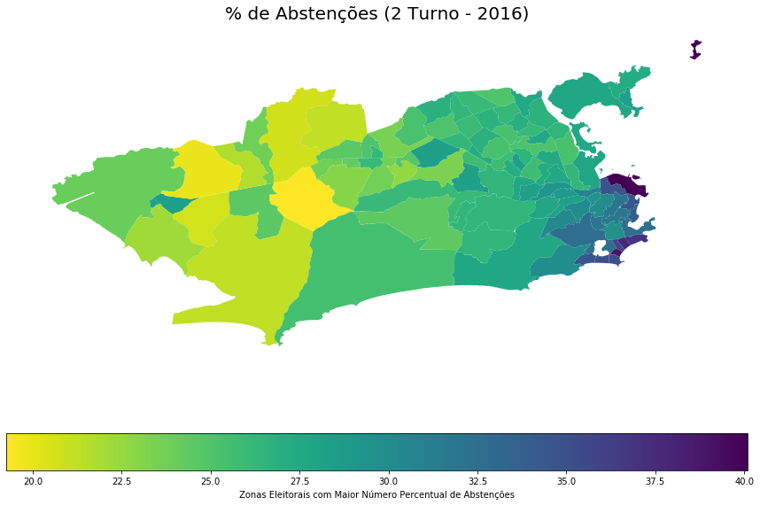

```python
#zonas eleitorais com maior número de abstencoes
ax = gpd_sum.plot(column = 'porcen_abstencoes',
                     figsize = (15,10), cmap = 'viridis_r', legend = True,
                           legend_kwds = {'label' :'Zonas Eleitorais com Maior Número Percentual de Abstenções',
                                          'orientation':'horizontal'})
ax.set_title('% de Abstenções (2 Turno - 2016)', fontsize = 20)
ax.axis('off');
```

- As zonas eleitorais que mais apresentaram abstenções foram as que se situam na Zona Sul e Centro, podendo chegar até quase 40%.

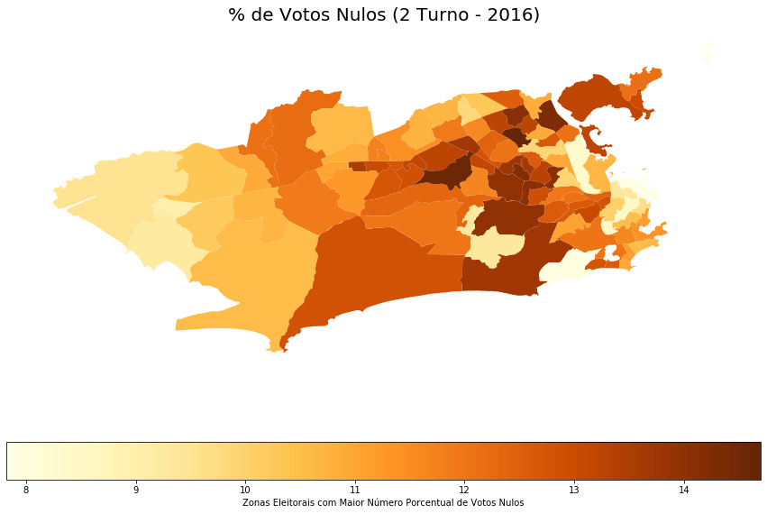

```python
#zonas eleitorais com maior número de votos nulos
ax = gpd_sum.plot(column = 'porcen_nulos',
                     figsize = (15,10), cmap = 'YlOrBr', legend = True,
                           legend_kwds = {'label' :'Zonas Eleitorais com Maior Número Porcentual de Votos Nulos',
                                          'orientation':'horizontal'})
ax.set_title('% de Votos Nulos (2 Turno - 2016)', fontsize = 20)
ax.axis('off');
```

- A distribuição dos votos nulos pela cidade foi reazoavelmente igual, variando entre 8 e 15%. Porém, é importante salientar que muito desses votos nulos vieram da Zona Norte e de parte da Zona Oeste.

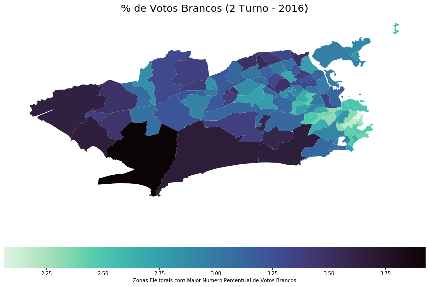

```python
#zonas eleitorais com maior número de votos brancos

ax = gpd_sum.plot(column = 'porcen_brancos',
                     figsize = (15,10), cmap = 'mako_r', legend = True,
                           legend_kwds = {'label' :'Zonas Eleitorais com Maior Número Percentual de Votos Brancos',
                                          'orientation':'horizontal'})
ax.set_title('% de Votos Brancos (2 Turno - 2016)', fontsize = 20)
ax.axis('off');
```

- As zonas com menor número de votos brancos foram a Zona Sul e o Centro. A Zona Oeste foi responsável pelo maior número porcentual de votos brancos.

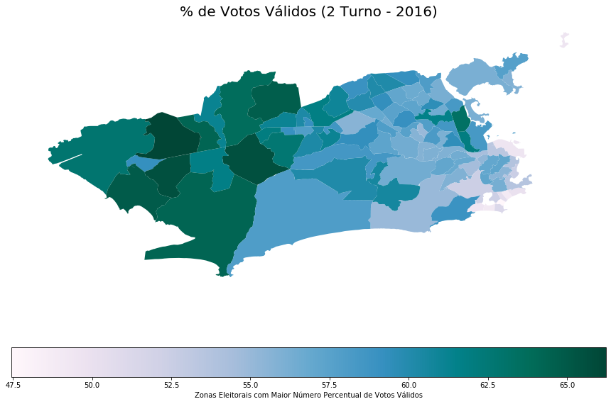

```python
#zonas eleitorais com maior número de votos válidos

ax = gpd_sum.plot(column = 'porcen_votos',
                     figsize = (15,10), cmap = 'PuBuGn', legend = True,
                           legend_kwds = {'label' :'Zonas Eleitorais com Maior Número Percentual de Votos Válidos',
                                          'orientation':'horizontal'})
ax.set_title('% de Votos Válidos (2 Turno - 2016)', fontsize = 20)
ax.axis('off');
```

- As Zonas Sul, Centro foram as zonas eleitorais com menor presença de votos válidos, uma vez que apresenta os maiores números de abstenções.Diferentemente da Zona Oeste, onde apresenta valores percentuais bem altos, em relação ao restante da cidade.

### Buscando Correlações

Voltar para o topo

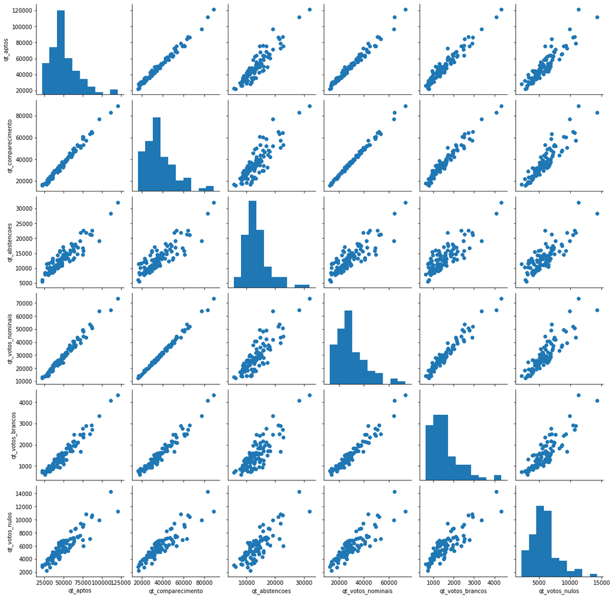

```python
g = sb.PairGrid(data = df_sum, vars = ['qt_aptos','qt_comparecimento','qt_abstencoes',
                                       'qt_votos_nominais','qt_votos_brancos', 'qt_votos_nulos'])
g.map_diag(plt.hist)
g.map_offdiag(plt.scatter)
```

```python
df_filter =df_sum.filter(['qt_aptos','qt_comparecimento','qt_abstencoes',
                          'qt_votos_nominais','qt_votos_brancos', 'qt_votos_nulos'])
```

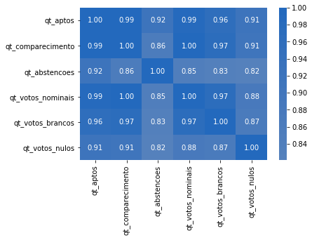

```python
#correlação entre votos brancos, nulos, abstenções e eleitores aptos,comparecimentos
sb.heatmap(df_filter.corr(), annot = True, fmt = '.2f', cmap = 'vlag_r', center = 0)
```

- Todas as variáveis possuem uma forte correlação. Variáveis como `qt_aptos`e `qt_comparecimento` tem uma justificativa bastante óbvia.
- A variável `qt_abstencoes`possui uma correlação mais fraca em relação às demais, assim como 'qt_votos_nulos'.

```python
abs_vn = x_abs.loc[x_abs == x_vn].to_list()
abs_br = x_abs.loc[x_abs == x_br].to_list()
br_vn = x_br.loc[x_abs == x_vn].to_list()

print('As zonas que compartilham o TOP 10 de Abstenções, Votos Nulos e Brancos são as seguintes: {}, {} e {}'.format(abs_vn,abs_br,br_vn))
```

[output not shown]

- As zonas eleitorais que mais tiveram presentes nos rankings de TOP 10 das eleições. É bastante compreensível, uma vez que possuem uma alta concentração populacional, além das zonas eleitorais abrangerem uma grande quantidade de bairros.

### Conclusões

- O número de abstenções foi o maior da história das eleições até então.
- O discurso do PSOL para as massas não foi bom o suficiente, já que ficou apenas nos bairros mais elitizados.
- Crivella já tinha uma certa fama por ser pastor, levando uma grande parcela de votos dos religiosos.
- Se a abstenção nas Zonas Centrais e Sul fossem menor, talvez o resultado final seria mais apertado, e quem sabe outro: Freixo prefeito
- O poder paralelo pode ter influência no voto, uma vez que Freixo foi o relator de uma CPI sobre as Milícias.

Voltar para o topo